# NESE males: isotopic structure, niche and repeatability

Luis Huckstadt

2026-11-10

# 1 Overview

Males have stable isotope values (δ¹³C, δ¹⁵N) and standard length, but no tracking or diving data. This script asks the same questions as the female analyses, with methods suited to those data. It replaces `NESE_NicheWidth_PostBreeding_Males.Rmd`, `NESE_NicheWidth_Males_PB.Rmd` and `NESE_MaleRepeatabilityIsotopes.Rmd`.

1. **Are there discrete isotopic groups?** Gaussian mixture models with correlated isotopes (1–4 groups, including “no groups”), a bootstrap likelihood-ratio test, and a null-model test of cluster structure.
2. **The isotopic gradient.** Each male’s position along the main axis of isotopic variation.
3. **What explains isotopic position?** Standard length, trip type and year. Length is tested as an explanation rather than used to define groups.
4. **Isotopic niche.** Niche size and directional overlap of males compared with each female strategy (nicheROVER and SIBER), with a sensitivity analysis restricted to females sampled in the same years as males.
5. **Repeatability.** Population-level repeatability and within-male differences compared with differences between males sampled in the same years (exploratory: few repeat males).

**Why the previous approach was replaced.** Clustering on δ¹³C, δ¹⁵N and length made groups partly size classes; `na.omit()` removed the males without length, leaving 13 post-breeding males for three clusters; isotopic niches of clusters defined by the same isotopes overlap little by construction; niches were estimated in three dimensions from 3–7 males with an unseeded random prior; and the repeatability script shared the problems of the female version (per-individual index, mislabelled IDs, hard-coded rows).

**Run first:** `NESE_PB_ForagingStrategies.Rmd` and `NESE_PM_ForagingStrategies.Rmd` (female strategies, for the sex comparison).

```r
library(dplyr)
library(tidyr)
library(ggplot2)
library(cluster)      # silhouette
library(nicheROVER)
library(rptR)
library(lme4)
# mclust and MASS are called with :: (attaching them masks dplyr functions)
```

# 2 Settings

```r
SEED <- 20261105
set.seed(SEED)

META_FILE <- "../data/IsotopesDatasetForLuis_2023_4_4.csv"
PB_ASSIGN <- "../results/PB_strategies/A_strategy_assignments.csv"
PM_ASSIGN <- "../results/PM_strategies/A_strategy_assignments.csv"

N_BOOT_LRT <- 999    # bootstrap replicates for the mixture-model LRT
N_NULL     <- 500    # simulations for the cluster-structure null model
N_PERM     <- 9999   # permutations
N_POST     <- 1e4    # nicheROVER posterior draws
N_RPT_BOOT <- 1000   # rptR bootstrap replicates
N_RPT_PERM <- 1000   # rptR permutations
MIN_GROUP_N <- 5     # smallest group used in niche comparisons

# SIBER (needs JAGS; section skipped if not installed)
SIBER_PARMS  <- list(n.iter = 2e4, n.burnin = 1e3, n.thin = 10, n.chains = 2)
SIBER_PRIORS <- list(R = 1 * diag(2), k = 2, tau.mu = 1.0E-3)
SIBER_DRAWS  <- 500
SIBER_P      <- 0.95
HAS_SIBER <- requireNamespace("SIBER", quietly = TRUE) && requireNamespace("rjags", quietly = TRUE)
if (!HAS_SIBER) message("SIBER/rjags (JAGS) not available: the SIBER section will be skipped.")

OUT <- "../results/males"
FIG <- "../figures/males"
dir.create(OUT, recursive = TRUE, showWarnings = FALSE)
dir.create(FIG, recursive = TRUE, showWarnings = FALSE)

ISO <- c("d13C", "d15N")
TRIP_LAB <- c(PostBreeding = "PB", PostMolt = "PM")
GROUP_COLS <- c("Males"                      = "#d73027",
                "Females PB: Subarctic"      = "#1b9e77",
                "Females PB: N Central Pacific" = "#d95f02",
                "Females PB: California Current" = "#7570b3",
                "Females PM"                 = "grey45")
```

## 2.1 Helper functions

```r
pick1 <- function(x) x[sample.int(length(x), 1)]

# Ward + k-means consolidation (as FactoMineR::HCPC)
hcpc_lite <- function(S, k) {
  cl  <- cutree(hclust(dist(S), method = "ward.D2"), k)
  cen <- apply(S, 2, function(x) tapply(x, cl, mean))
  tryCatch(kmeans(S, centers = cen, iter.max = 100)$cluster, error = function(e) cl)
}

# Freedman-Lane permutation F test for `term`, adjusting for `covars`
fl_test <- function(d, response, term, covars = character(0), B = N_PERM) {
  v  <- c(response, term, covars)
  d  <- d[complete.cases(d[v]), v, drop = FALSE]
  X0 <- model.matrix(reformulate(if (length(covars)) covars else "1"), d)
  X1 <- model.matrix(reformulate(c(covars, term)), d)
  y  <- d[[response]]
  Fstat <- function(y) {
    m0 <- lm.fit(X0, y); m1 <- lm.fit(X1, y)
    r0 <- sum(m0$residuals^2); r1 <- sum(m1$residuals^2)
    ((r0 - r1) / (m1$rank - m0$rank)) / (r1 / (nrow(X1) - m1$rank))
  }
  F_obs <- Fstat(y)
  m0 <- lm.fit(X0, y); fit0 <- y - m0$residuals
  F_p <- replicate(B, Fstat(fit0 + sample(m0$residuals)))
  data.frame(response = response, term = term,
             covariates = if (length(covars)) paste(covars, collapse = " + ") else "none",
             n = nrow(d), F = F_obs, p_perm = (1 + sum(F_p >= F_obs)) / (B + 1))
}

# rptR without progress bars, and results read from its printed summary
fit_rpt <- function(...) { out <- NULL; invisible(capture.output(out <- rpt(...))); out }
rpt_parse <- function(r, comp) {
  txt <- capture.output(print(summary(r)))
  i <- grep(paste0("^\\s*", comp, " \\("), txt)[1]
  if (is.na(i)) return(NULL)
  k <- grep("Repeatability estimation overview", txt); k <- k[k > i][1]
  if (is.na(k)) return(NULL)
  hdr  <- strsplit(trimws(txt[k + 1]), "\\s+")[[1]]
  vals <- suppressWarnings(as.numeric(strsplit(trimws(txt[k + 2]), "\\s+")[[1]]))
  if (length(hdr) != length(vals)) return(NULL)
  setNames(vals, hdr)
}
rpt_row <- function(r, label, n_obs, n_ind, n_rep) {
  v <- if (is.null(r)) NULL else rpt_parse(r, "MainID")
  g <- function(x, nm) if (!is.null(x) && nm %in% names(x)) unname(x[[nm]]) else NA_real_
  if (is.null(v) && !is.null(r)) { message("Could not read R for ", label); print(summary(r)) }
  data.frame(variable = label, n_obs = n_obs, n_males = n_ind, n_repeat_males = n_rep,
             R = g(v, "R"), SE = g(v, "SE"), lwr = g(v, "2.5%"), upr = g(v, "97.5%"),
             P_LRT = g(v, "LRT_P"), P_permut = g(v, "P_permut"))
}

# All within-individual pairs of samples
within_pairs <- function(d) {
  d %>% group_by(MainID) %>% filter(n() > 1) %>%
    group_modify(function(g, key) {
      ij <- t(combn(nrow(g), 2))
      data.frame(row_1 = g$row[ij[, 1]], row_2 = g$row[ij[, 2]],
                 trip_1 = g$trip[ij[, 1]], trip_2 = g$trip[ij[, 2]],
                 year_1 = g$year[ij[, 1]], year_2 = g$year[ij[, 2]])
    }) %>% ungroup() %>% mutate(lag_years = abs(year_2 - year_1))
}
```

# 3 Data

```r
meta <- read.csv(META_FILE)

males <- meta %>%
  filter(Sex == "Male", TimePeriod == "Arrival", !is.na(d13C), !is.na(d15N)) %>%
  transmute(MainID = as.character(MainID), TOPPID = as.character(TOPPID),
            trip = unname(TRIP_LAB[as.character(Trip)]), year = as.integer(ProcedureYear),
            length_cm = StandardLength_cm, d13C, d15N) %>%
  filter(!is.na(trip)) %>%
  arrange(year, trip) %>% mutate(row = row_number(), Trip = factor(trip), Year = factor(year))

cat(nrow(males), "samples from", n_distinct(males$MainID), "males;",
    sum(table(males$MainID) > 1), "males sampled more than once\n")
```

```
## 48 samples from 40 males; 6 males sampled more than once
```

```r
table(males$trip, males$year)
```

```
##
##      2011 2012 2013
##   PB   13    3    7
##   PM    2   13   10
```

```r
cat("Samples without standard length:", sum(is.na(males$length_cm)), "\n")
```

```
## Samples without standard length: 10
```

```r
# One sample per male (earliest) for analyses that assume independent individuals
males1 <- males %>% distinct(MainID, .keep_all = TRUE)

# Females: tracked strategies with isotopes
fem_iso <- meta %>% transmute(TOPPID = as.character(TOPPID), d13C, d15N) %>% distinct(TOPPID, .keep_all = TRUE)
females <- bind_rows(
  read.csv(PB_ASSIGN) %>% transmute(TOPPID = as.character(TOPPID), MainID = as.character(MainID),
                                    year = ProcedureYear, trip = "PB",
                                    group = paste("Females PB:", recode(strategy,
                                      "North Central Pacific" = "N Central Pacific"))),
  read.csv(PM_ASSIGN) %>% transmute(TOPPID = as.character(TOPPID), MainID = as.character(MainID),
                                    year = ProcedureYear, trip = "PM", group = "Females PM")) %>%
  left_join(fem_iso, by = "TOPPID") %>% filter(!is.na(d13C), !is.na(d15N))
table(females$group)
```

```
##
## Females PB: California Current  Females PB: N Central Pacific
##                              6                             39
##          Females PB: Subarctic                     Females PM
##                             48                             86
```

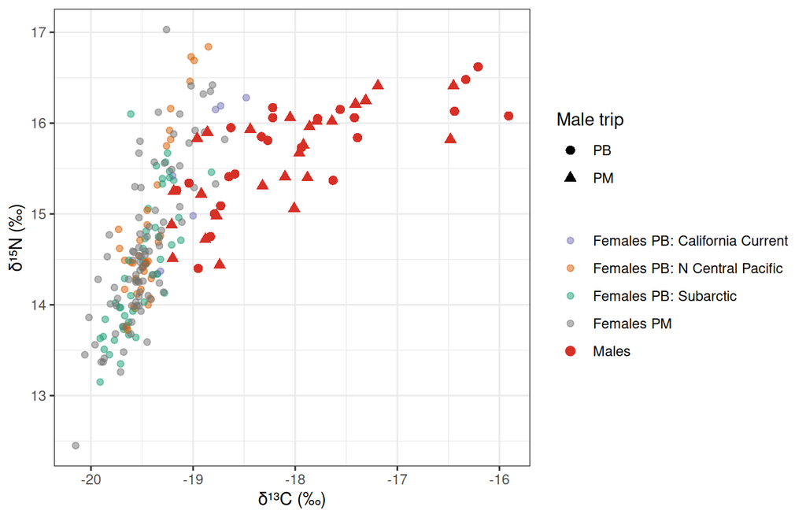

```r
g <- ggplot() +
  geom_point(data = females, aes(d13C, d15N, colour = group), alpha = 0.5, size = 1.6) +
  geom_point(data = males, aes(d13C, d15N, colour = "Males", shape = trip), size = 2.4) +
  scale_colour_manual(values = GROUP_COLS, name = NULL) +
  scale_shape_manual(values = c(PB = 16, PM = 17), name = "Male trip") +
  theme_bw() + labs(x = "δ¹³C (‰)", y = "δ¹⁵N (‰)")
g
```

```r
ggsave(file.path(FIG, "0_males_vs_female_strategies.pdf"), g, width = 8, height = 5, device = cairo_pdf)
```

# 4 1. Are there discrete isotopic groups?

## 4.1 Gaussian mixture models

δ¹³C and δ¹⁵N are strongly correlated, so models must allow correlated (ellipsoidal) groups; models that assume uncorrelated isotopes can split one elongated cloud into spurious groups. Models with 1–4 groups are compared by BIC (higher is better in `mclust`); one group means no discrete structure.

```r
Z1 <- scale(males1[ISO])
cor(males1$d13C, males1$d15N, method = "spearman")
```

```
## [1] 0.808858
```

```r
bic1 <- mclust::mclustBIC(Z1, G = 1:4)
summary(bic1)
```

```
## Best BIC values:
##              EEV,2       EII,3       EVV,2
## BIC      -208.5917 -209.955745 -210.565890
## BIC diff    0.0000   -1.364009   -1.974154
```

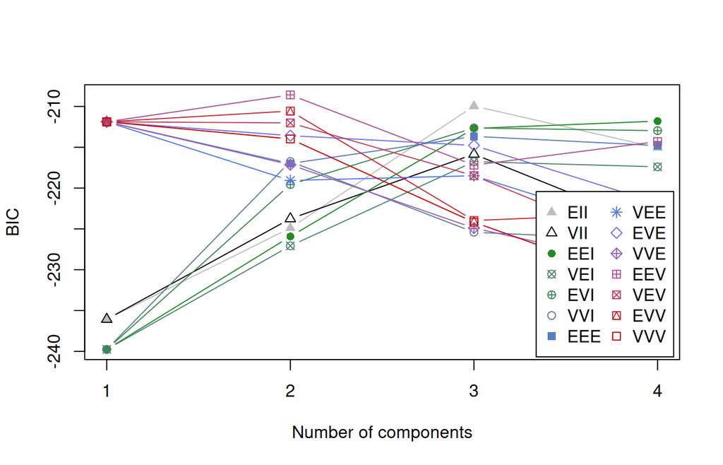

```r
plot(bic1)
```

```r
# Best model among those allowing correlated isotopes (full covariance)
full_models <- c("EEE", "VVV", "EEV", "VEV", "EVE", "VVE", "EVV", "VEE")
bic_full <- bic1[, intersect(full_models, colnames(bic1)), drop = FALSE]
best <- which(bic_full == max(bic_full, na.rm = TRUE), arr.ind = TRUE)[1, ]
cat("Best correlated model:", colnames(bic_full)[best[2]], "with G =", rownames(bic_full)[best[1]], "\n")
```

```
## Best correlated model: EEV with G = 2
```

```r
round(bic_full, 1)
```

```
##      EEE    VVV    EEV    VEV    EVE    VVE    EVV    VEE
## 1 -211.9 -211.9 -211.9 -211.9 -211.9 -211.9 -211.9 -211.9
## 2 -217.0 -214.0 -208.6 -212.0 -213.6 -217.1 -210.6 -219.1
## 3 -213.7 -224.2 -217.2 -218.5 -214.8 -224.9 -224.0 -218.5
## 4 -214.8 -232.1 -214.3 -227.7 -221.8 -229.9 -223.0 -225.6
```

```r
# Sensitivity: all samples
bic_all <- mclust::mclustBIC(scale(males[ISO]), G = 1:4)
summary(bic_all)
```

```
## Best BIC values:
##              EEV,2        EII,3       EVV,2
## BIC      -250.8717 -251.7745273 -253.438573
## BIC diff    0.0000   -0.9028631   -2.566909
```

## 4.2 Bootstrap likelihood-ratio test (1 vs 2 vs 3 groups)

```r
set.seed(SEED)
lrt <- mclust::mclustBootstrapLRT(Z1, modelName = "VVV", nboot = N_BOOT_LRT, maxG = 2, verbose = FALSE)
lrt
```

```
## -------------------------------------------------------------
## Bootstrap sequential LRT for the number of mixture components
## -------------------------------------------------------------
## Model        = VVV
## Replications = 999
##              LRTS bootstrap p-value
## 1 vs 2   20.03015             0.055
## 2 vs 3   11.93462             0.423
```

## 4.3 Null-model test of cluster structure

The silhouette of Ward + k-means clusters is compared with that obtained from data simulated from a single bivariate normal distribution with the observed means and covariance (one correlated cloud, no groups).

```r
mu <- colMeans(Z1); Sg <- cov(Z1)
set.seed(SEED)
null_struct <- do.call(rbind, lapply(2:4, function(k) {
  obs <- mean(silhouette(hcpc_lite(Z1, k), dist(Z1))[, 3])
  sim <- replicate(N_NULL, {
    Y <- MASS::mvrnorm(nrow(Z1), mu, Sg)
    mean(silhouette(hcpc_lite(Y, k), dist(Y))[, 3])
  })
  data.frame(k = k, silhouette = obs, null_median = median(sim),
             null_95 = quantile(sim, 0.95), p = (1 + sum(sim >= obs)) / (N_NULL + 1))
}))
rownames(null_struct) <- NULL
null_struct %>% mutate(across(where(is.double), ~ round(.x, 3)))
```

```
##   k silhouette null_median null_95     p
## 1 2      0.474       0.475   0.543 0.505
## 2 3      0.473       0.428   0.501 0.128
## 3 4      0.389       0.399   0.468 0.625
```

```r
write.csv(null_struct, file.path(OUT, "1_null_structure.csv"), row.names = FALSE)
```

**Interpretation.** Discrete groups are supported only if a correlated mixture model with ≥ 2 groups clearly beats one group (ΔBIC > 6), the bootstrap LRT rejects one group, and the silhouette exceeds the null. Otherwise, describe male isotopes as a continuum (Section 2).

# 5 2. The isotopic gradient

The first principal component of the standardised isotopes summarises the main axis of variation; positive scores = higher δ¹³C (and δ¹⁵N), i.e. more coastal / continental-margin values; negative = more oceanic.

```r
pca_iso <- prcomp(males[ISO], center = TRUE, scale. = TRUE)
males$gradient <- pca_iso$x[, 1] * sign(cor(pca_iso$x[, 1], males$d13C))
summary(pca_iso)$importance[, 1]
```

```
##     Standard deviation Proportion of Variance  Cumulative Proportion
##               1.312605               0.861470               0.861470
```

```r
round(pca_iso$rotation, 2)
```

```
##       PC1   PC2
## d13C 0.71  0.71
## d15N 0.71 -0.71
```

```r
if (requireNamespace("diptest", quietly = TRUE)) {
  print(diptest::dip.test(males$gradient[!duplicated(males$MainID)]))
} else message("Install 'diptest' for a formal test of unimodality.")
```

```
##
##  Hartigans' dip test for unimodality / multimodality
##
## data:  males$gradient[!duplicated(males$MainID)]
## D = 0.050785, p-value = 0.6116
## alternative hypothesis: non-unimodal, i.e., at least bimodal
```

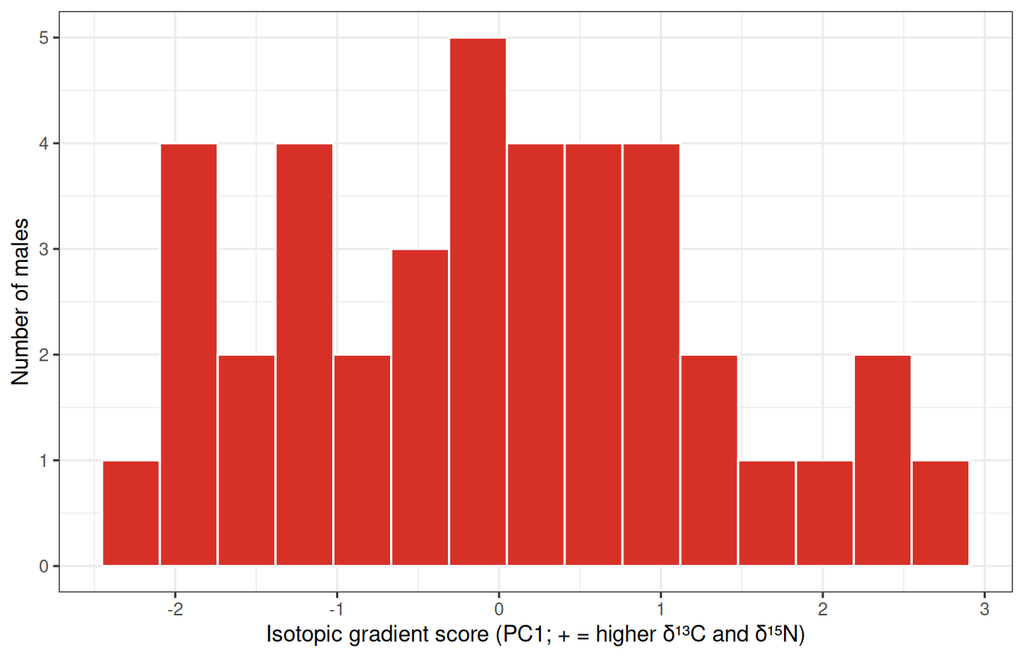

```r
g <- ggplot(males %>% distinct(MainID, .keep_all = TRUE), aes(gradient)) +
  geom_histogram(bins = 15, fill = "#d73027", colour = "white") + theme_bw() +
  labs(x = "Isotopic gradient score (PC1; + = higher δ¹³C and δ¹⁵N)",
       y = "Number of males")
g
```

```r
ggsave(file.path(FIG, "2_gradient_distribution.pdf"), g, width = 7, height = 4, device = cairo_pdf)
write.csv(males, file.path(OUT, "2_males_with_gradient.csv"), row.names = FALSE)
```

# 6 3. What explains isotopic position?

One sample per male (earliest with length data). Each term is tested with Freedman–Lane permutation tests adjusting for the others.

```r
ml <- males %>% filter(!is.na(length_cm)) %>% distinct(MainID, .keep_all = TRUE)
cat(nrow(ml), "males with standard length\n")
```

```
## 30 males with standard length
```

```r
set.seed(SEED)
expl <- bind_rows(lapply(c(ISO, "gradient"), function(v) bind_rows(
  fl_test(ml, v, "length_cm", c("Trip", "Year")),
  fl_test(ml, v, "Trip",      c("length_cm", "Year")),
  fl_test(ml, v, "Year",      c("length_cm", "Trip")))))
expl$p_BH <- p.adjust(expl$p_perm, "BH")
expl %>% mutate(across(c(F, p_perm, p_BH), ~ signif(.x, 3)))
```

```
##   response      term       covariates  n      F p_perm  p_BH
## 1     d13C length_cm      Trip + Year 30 0.6250 0.4350 0.652
## 2     d13C      Trip length_cm + Year 30 2.7600 0.1080 0.325
## 3     d13C      Year length_cm + Trip 30 2.8900 0.0779 0.325
## 4     d15N length_cm      Trip + Year 30 0.0246 0.8780 0.878
## 5     d15N      Trip length_cm + Year 30 0.1740 0.6740 0.841
## 6     d15N      Year length_cm + Trip 30 2.0100 0.1630 0.366
## 7 gradient length_cm      Trip + Year 30 0.0986 0.7480 0.841
## 8 gradient      Trip length_cm + Year 30 1.1600 0.2980 0.537
## 9 gradient      Year length_cm + Trip 30 2.7400 0.0830 0.325
```

```r
write.csv(expl, file.path(OUT, "3_explanatory_tests.csv"), row.names = FALSE)

# Slopes per 10 cm of length
sapply(setNames(ISO, ISO), function(v) {
  f <- lm(reformulate(c("length_cm", "Trip", "Year"), v), data = ml)
  round(c(slope_per_10cm = 10 * coef(f)[["length_cm"]], 10 * confint(f)["length_cm", ]), 3)
})
```

```
##                  d13C   d15N
## slope_per_10cm -0.052  0.007
## 2.5 %          -0.187 -0.089
## 97.5 %          0.083  0.104
```

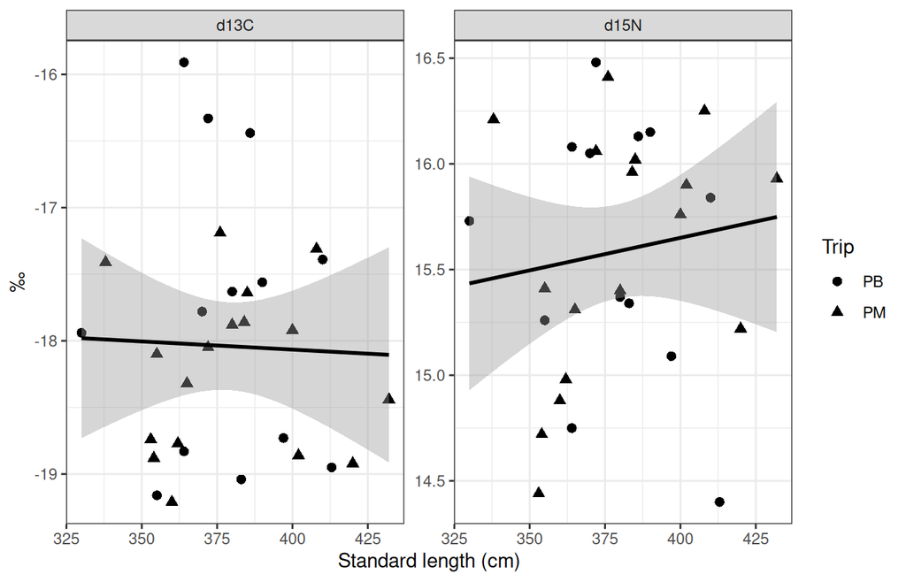

```r
g <- ml %>% pivot_longer(all_of(ISO), names_to = "isotope") %>%
  ggplot(aes(length_cm, value)) + geom_point(aes(shape = trip), size = 2.2) +
  geom_smooth(method = "lm", formula = y ~ x, colour = "black") +
  facet_wrap(~ isotope, scales = "free_y") + theme_bw() +
  labs(x = "Standard length (cm)", y = "‰", shape = "Trip")
g
```

```r
ggsave(file.path(FIG, "3_isotopes_vs_length.pdf"), g, width = 8, height = 4, device = cairo_pdf)
```

# 7 4. Isotopic niche: males vs female strategies

Males (one sample per male) are compared with each female strategy (Post-Breeding strategies; Post-Moult females as one group, since they form a continuum). None of these groups were defined from isotopes, so differences are not circular.

```r
niche_dat <- bind_rows(
  males1 %>% transmute(group = "Males", year, d13C, d15N),
  females %>% transmute(group, year, d13C, d15N)) %>%
  group_by(group) %>% filter(n() >= MIN_GROUP_N) %>% ungroup() %>%
  mutate(group = factor(group, intersect(names(GROUP_COLS), unique(group))))
table(niche_dat$group)
```

```
##
##                          Males          Females PB: Subarctic
##                             40                             48
##  Females PB: N Central Pacific Females PB: California Current
##                             39                              6
##                     Females PM
##                             86
```

```r
# Mean differences: males vs each female group (Welch t-tests, BH-adjusted)
mdiff <- bind_rows(lapply(setdiff(levels(niche_dat$group), "Males"), function(gr) bind_rows(lapply(ISO, function(v) {
  tt <- t.test(niche_dat[[v]][niche_dat$group == "Males"], niche_dat[[v]][niche_dat$group == gr])
  data.frame(comparison = paste("Males -", gr), isotope = v,
             difference = unname(diff(rev(tt$estimate))), lwr = tt$conf.int[1], upr = tt$conf.int[2],
             p = tt$p.value)
}))))
mdiff$p_BH <- p.adjust(mdiff$p, "BH")
mdiff %>% mutate(across(where(is.double), ~ signif(.x, 3)))
```

```
##                               comparison isotope difference    lwr   upr
## 1          Males - Females PB: Subarctic    d13C     1.4400  1.160 1.710
## 2          Males - Females PB: Subarctic    d15N     1.2200  0.947 1.490
## 3  Males - Females PB: N Central Pacific    d13C     1.3700  1.100 1.650
## 4  Males - Females PB: N Central Pacific    d15N     0.8650  0.535 1.190
## 5 Males - Females PB: California Current    d13C     0.8550  0.469 1.240
## 6 Males - Females PB: California Current    d15N     0.0825 -0.732 0.897
## 7                     Males - Females PM    d13C     1.4000  1.130 1.680
## 8                     Males - Females PM    d15N     1.0100  0.755 1.270
##          p     p_BH
## 1 1.23e-13 4.94e-13
## 2 9.66e-14 4.94e-13
## 3 5.39e-13 1.08e-12
## 4 1.88e-06 2.50e-06
## 5 1.88e-04 2.15e-04
## 6 8.11e-01 8.11e-01
## 7 2.87e-13 7.66e-13
## 8 3.47e-12 5.55e-12
```

```r
write.csv(mdiff, file.path(OUT, "4_male_female_differences.csv"), row.names = FALSE)
```

## 7.1 nicheROVER: niche size and directional overlap

```r
run_niche <- function(d, nsamples = N_POST) {
  d$group <- droplevels(d$group)
  set.seed(SEED)
  par <- tapply(seq_len(nrow(d)), d$group,
                function(ii) niw.post(nsamples = nsamples, X = as.matrix(d[ii, ISO])))
  seab <- sapply(par, function(sp) apply(sp$Sigma, 3, function(S) pi * sqrt(det(S))))
  nr95 <- sapply(par, function(sp) apply(sp$Sigma, 3, niche.size, alpha = 0.95))
  set.seed(SEED)
  ov <- overlap(par, nreps = nsamples, nprob = nsamples, alpha = c(0.95, 0.99))
  list(par = par, seab = seab, nr95 = nr95, overlap = ov)
}
nb <- run_niche(niche_dat)
lev <- colnames(nb$seab)
sea_c <- tapply(seq_len(nrow(niche_dat)), niche_dat$group, function(ii) {
  m <- length(ii); pi * sqrt(det(cov(niche_dat[ii, ISO]))) * (m - 1) / (m - 2) })
size_tab <- data.frame(group = lev, n = as.vector(table(niche_dat$group)[lev]),
  SEAc = as.vector(sea_c[lev]),
  SEAb_median = apply(nb$seab, 2, median),
  SEAb_lwr = apply(nb$seab, 2, quantile, 0.025), SEAb_upr = apply(nb$seab, 2, quantile, 0.975),
  NR95_median = apply(nb$nr95, 2, median))
size_tab %>% mutate(across(where(is.double), ~ round(.x, 3)))
```

```
##                                                         group  n  SEAc
## Males                                                   Males 40 1.024
## Females PB: Subarctic                   Females PB: Subarctic 48 0.372
## Females PB: N Central Pacific   Females PB: N Central Pacific 39 0.280
## Females PB: California Current Females PB: California Current  6 0.452
## Females PM                                         Females PM 86 0.511
##                                SEAb_median SEAb_lwr SEAb_upr NR95_median
## Males                                0.958    0.716    1.319       5.739
## Females PB: Subarctic                0.351    0.269    0.475       2.105
## Females PB: N Central Pacific        0.260    0.194    0.363       1.558
## Females PB: California Current       0.272    0.138    0.643       1.629
## Females PM                           0.495    0.403    0.617       2.969
```

```r
write.csv(size_tab, file.path(OUT, "4_niche_size.csv"), row.names = FALSE)

# P(male niche larger than each female group's)
round(sapply(setdiff(lev, "Males"), function(gr) mean(nb$seab[, "Males"] > nb$seab[, gr])), 3)
```

```
##          Females PB: Subarctic  Females PB: N Central Pacific
##                          1.000                          1.000
## Females PB: California Current                     Females PM
##                          0.995                          1.000
```

```r
# Directional overlap (%): P(an individual of the row group falls in the column group's 95% niche)
ov_mean <- apply(nb$overlap, c(1:2, 4), mean) * 100
ov_ci   <- apply(nb$overlap * 100, c(1:2, 4), quantile, prob = c(0.025, 0.975), na.rm = TRUE)
round(ov_mean[, , 1], 1)
```

```
##                                 Species B
## Species A                        Males Females PB: Subarctic
##   Males                             NA                  11.3
##   Females PB: Subarctic           52.5                    NA
##   Females PB: N Central Pacific   57.6                  90.7
##   Females PB: California Current  71.9                  45.0
##   Females PM                      54.6                  85.2
##                                 Species B
## Species A                        Females PB: N Central Pacific
##   Males                                                    7.0
##   Females PB: Subarctic                                   79.5
##   Females PB: N Central Pacific                             NA
##   Females PB: California Current                          22.8
##   Females PM                                              71.7
##                                 Species B
## Species A                        Females PB: California Current Females PM
##   Males                                                    16.4       14.5
##   Females PB: Subarctic                                    41.9       97.0
##   Females PB: N Central Pacific                            38.1       96.7
##   Females PB: California Current                             NA       63.7
##   Females PM                                               39.9         NA
```

```r
ov_long <- expand.grid(from = lev, into = lev, stringsAsFactors = FALSE) %>%
  filter(from != into, from == "Males" | into == "Males") %>%
  mutate(mean = mapply(function(a, b) ov_mean[a, b, 1], from, into),
         lwr  = mapply(function(a, b) ov_ci[1, a, b, 1], from, into),
         upr  = mapply(function(a, b) ov_ci[2, a, b, 1], from, into))
ov_long %>% mutate(across(where(is.double), ~ round(.x, 1)))
```

```
##                             from                           into mean  lwr  upr
## 1          Females PB: Subarctic                          Males 52.5 31.1 74.2
## 2  Females PB: N Central Pacific                          Males 57.6 37.2 75.7
## 3 Females PB: California Current                          Males 71.9 39.4 95.3
## 4                     Females PM                          Males 54.6 34.8 72.0
## 5                          Males          Females PB: Subarctic 11.3  5.4 18.4
## 6                          Males  Females PB: N Central Pacific  7.0  3.2 11.8
## 7                          Males Females PB: California Current 16.4  7.7 31.2
## 8                          Males                     Females PM 14.5  7.6 22.6
```

```r
write.csv(ov_long, file.path(OUT, "4_niche_overlap_95.csv"), row.names = FALSE)
```

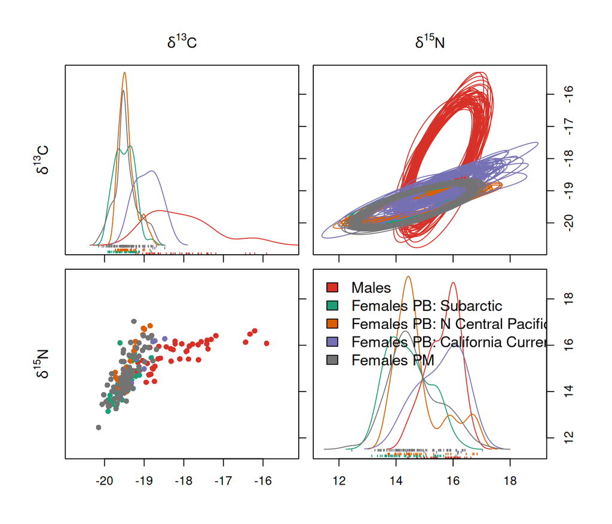

```r
cols <- unname(GROUP_COLS[lev])
set.seed(SEED)
par50 <- tapply(seq_len(nrow(niche_dat)), niche_dat$group,
                function(ii) niw.post(nsamples = 50, X = as.matrix(niche_dat[ii, ISO])))
dl <- tapply(seq_len(nrow(niche_dat)), niche_dat$group, function(ii) as.matrix(niche_dat[ii, ISO]))
niche.plot(niche.par = par50, niche.data = dl, pfrac = 0.05,
           iso.names = expression(delta^{13}*C, delta^{15}*N), col = cols)
```

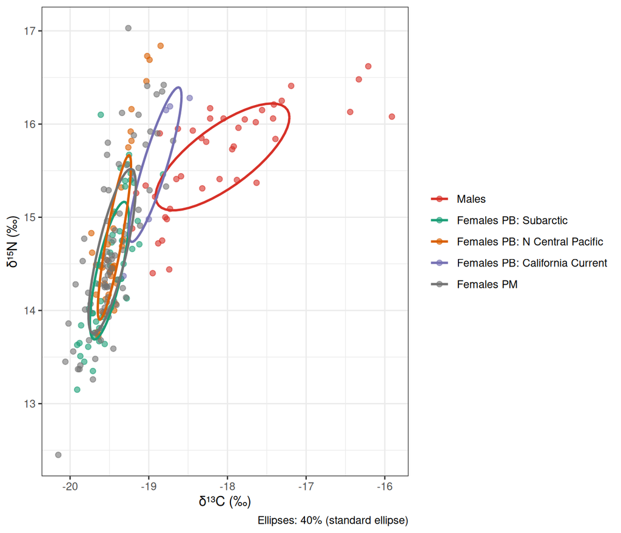

```r
g <- ggplot(niche_dat, aes(d13C, d15N, colour = group)) +
  geom_point(alpha = 0.6, size = 1.8) +
  stat_ellipse(level = 0.40, type = "norm", linewidth = 0.9) +
  scale_colour_manual(values = GROUP_COLS, name = NULL) + theme_bw() +
  labs(x = "δ¹³C (‰)", y = "δ¹⁵N (‰)",
       caption = "Ellipses: 40% (standard ellipse)")
g
```

```r
ggsave(file.path(FIG, "4_niche_ellipses.pdf"), g, width = 8, height = 5, device = cairo_pdf)
```

## 7.2 SIBER: standard ellipse areas and ellipse overlap

```r
codes <- setNames(paste0("G", seq_along(lev)), lev)
siber <- SIBER::createSiberObject(data.frame(iso1 = niche_dat$d13C, iso2 = niche_dat$d15N,
                                             group = unname(codes[as.character(niche_dat$group)]),
                                             community = 1))
ell_id <- setNames(paste0("1.", codes), lev)
ml_siber <- SIBER::groupMetricsML(siber); colnames(ml_siber) <- lev[match(colnames(ml_siber), ell_id)]
round(ml_siber, 3)
```

```
##      Males Females PB: Subarctic Females PB: N Central Pacific
## TA   3.538                 1.562                         0.918
## SEA  0.998                 0.364                         0.272
## SEAc 1.024                 0.372                         0.280
##      Females PB: California Current Females PM
## TA                            0.461      2.736
## SEA                           0.362      0.505
## SEAc                          0.452      0.511
```

```r
set.seed(SEED)
ell_post <- SIBER::siberMVN(siber, SIBER_PARMS, SIBER_PRIORS)
sea_b <- SIBER::siberEllipses(ell_post); colnames(sea_b) <- lev[match(names(ell_post), ell_id)]
siber_size <- data.frame(group = colnames(sea_b), SEAc = ml_siber["SEAc", colnames(sea_b)],
                         SEAb_median = apply(sea_b, 2, median),
                         SEAb_lwr = apply(sea_b, 2, quantile, 0.025),
                         SEAb_upr = apply(sea_b, 2, quantile, 0.975), row.names = NULL)
siber_size %>% mutate(across(where(is.double), ~ round(.x, 3)))
```

```
##                            group  SEAc SEAb_median SEAb_lwr SEAb_upr
## 1                          Males 1.024       1.035    0.773    1.446
## 2          Females PB: Subarctic 0.372       0.376    0.286    0.509
## 3  Females PB: N Central Pacific 0.280       0.298    0.221    0.417
## 4 Females PB: California Current 0.452       0.555    0.267    1.467
## 5                     Females PM 0.511       0.516    0.423    0.643
```

```r
write.csv(siber_size, file.path(OUT, "4_SIBER_niche_size.csv"), row.names = FALSE)

q3 <- function(x) sprintf("%.2f (%.2f-%.2f)", median(x, na.rm = TRUE),
                          quantile(x, .025, na.rm = TRUE), quantile(x, .975, na.rm = TRUE))
set.seed(SEED)
siber_ov <- bind_rows(lapply(setdiff(lev, "Males"), function(gr) {
  b <- SIBER::bayesianOverlap(ell_id[["Males"]], ell_id[[gr]], ell_post,
                              draws = SIBER_DRAWS, p.interval = SIBER_P, n = 100)
  data.frame(comparison = paste("Males vs", gr),
             prop_of_union = q3(b$overlap / (b$area1 + b$area2 - b$overlap)),
             prop_of_male_ellipse = q3(b$overlap / b$area1),
             prop_of_female_ellipse = q3(b$overlap / b$area2))
}))
siber_ov
```

```
##                                comparison    prop_of_union prop_of_male_ellipse
## 1          Males vs Females PB: Subarctic 0.15 (0.08-0.21)     0.17 (0.11-0.25)
## 2  Males vs Females PB: N Central Pacific 0.11 (0.05-0.15)     0.13 (0.07-0.17)
## 3 Males vs Females PB: California Current 0.20 (0.08-0.38)     0.26 (0.11-0.52)
## 4                     Males vs Females PM 0.17 (0.10-0.23)     0.22 (0.14-0.28)
##   prop_of_female_ellipse
## 1       0.48 (0.26-0.67)
## 2       0.44 (0.21-0.61)
## 3       0.51 (0.15-0.86)
## 4       0.44 (0.25-0.60)
```

```r
write.csv(siber_ov, file.path(OUT, "4_SIBER_overlap.csv"), row.names = FALSE)
```

## 7.3 Sensitivity: females from the same years as males

Males were sampled only in 2011–2013. Isotopic baselines vary among years, so the comparison is repeated with females from the same years only (groups with fewer than `MIN_GROUP_N` females are dropped).

```r
yrs <- unique(males$year)
nd_y <- bind_rows(
  males1 %>% transmute(group = "Males", year, d13C, d15N),
  females %>% filter(year %in% yrs) %>% transmute(group, year, d13C, d15N)) %>%
  group_by(group) %>% filter(n() >= MIN_GROUP_N) %>% ungroup() %>%
  mutate(group = factor(group, intersect(names(GROUP_COLS), unique(group))))
table(nd_y$group)
```

```
##
##                         Males         Females PB: Subarctic
##                            40                            20
## Females PB: N Central Pacific                    Females PM
##                            26                            27
```

```r
# Male - female differences adjusted for year
set.seed(SEED)
bind_rows(lapply(setdiff(levels(nd_y$group), "Males"), function(gr) bind_rows(lapply(ISO, function(v) {
  d <- nd_y %>% filter(group %in% c("Males", gr)) %>%
    mutate(group = relevel(droplevels(group), "Males"), Year = factor(year))
  f <- lm(reformulate(c("group", "Year"), v), data = d)
  cf <- coef(f)[2]; ci <- confint(f)[2, ]
  data.frame(comparison = paste("Males -", gr), isotope = v,
             difference = -unname(cf), lwr = -unname(ci[2]), upr = -unname(ci[1]),
             p_perm = fl_test(d, v, "group", "Year", B = 4999)$p_perm)
})))) %>% mutate(across(where(is.double), ~ signif(.x, 3)))
```

```
##                              comparison isotope difference   lwr  upr p_perm
## 1         Males - Females PB: Subarctic    d13C      1.520 1.130 1.91  2e-04
## 2         Males - Females PB: Subarctic    d15N      1.440 1.110 1.78  2e-04
## 3 Males - Females PB: N Central Pacific    d13C      1.350 1.010 1.68  2e-04
## 4 Males - Females PB: N Central Pacific    d15N      0.843 0.489 1.20  2e-04
## 5                    Males - Females PM    d13C      1.610 1.240 1.98  2e-04
## 6                    Males - Females PM    d15N      1.160 0.750 1.57  2e-04
```

```r
nb_y <- run_niche(nd_y, nsamples = 5000)
round(apply(nb_y$overlap, c(1:2, 4), mean)[, , 1] * 100, 1)
```

```
##                                Species B
## Species A                       Males Females PB: Subarctic
##   Males                            NA                   9.4
##   Females PB: Subarctic          43.2                    NA
##   Females PB: N Central Pacific  57.4                  75.2
##   Females PM                     50.0                  75.5
##                                Species B
## Species A                       Females PB: N Central Pacific Females PM
##   Males                                                   6.8       12.7
##   Females PB: Subarctic                                  73.9       95.6
##   Females PB: N Central Pacific                            NA       93.5
##   Females PM                                             67.7         NA
```

```r
round(apply(nb_y$seab, 2, median), 3)
```

```
##                         Males         Females PB: Subarctic
##                         0.960                         0.274
## Females PB: N Central Pacific                    Females PM
##                         0.247                         0.453
```

# 8 5. Repeatability

## 8.1 Population-level repeatability

All males are used (males sampled once help estimate the variance components). Year is a fixed effect, because three years are too few for a random effect. With only 6 repeat males, the estimates are exploratory and CIs will be wide.

```r
rep_ids <- names(which(table(males$MainID) > 1))
set.seed(SEED)
rpt_tab <- bind_rows(lapply(ISO, function(v) {
  d_rep <- males %>% filter(MainID %in% rep_ids) %>% mutate(MainID = factor(MainID))
  d_all <- males %>% mutate(MainID = factor(MainID))
  ra <- tryCatch(fit_rpt(reformulate(c("Trip", "(1 | MainID)"), v), grname = "MainID", data = d_rep,
                         datatype = "Gaussian", nboot = N_RPT_BOOT, npermut = N_RPT_PERM),
                 error = function(e) NULL)
  rb <- tryCatch(fit_rpt(reformulate(c("Trip", "Year", "(1 | MainID)"), v), grname = "MainID", data = d_all,
                         datatype = "Gaussian", nboot = N_RPT_BOOT, npermut = N_RPT_PERM),
                 error = function(e) NULL)
  bind_rows(
    rpt_row(ra, paste(v, "(a) original: repeat males, trip"), nrow(d_rep), length(rep_ids), length(rep_ids)),
    rpt_row(rb, paste(v, "(b) all males, trip + year"), nrow(d_all), nlevels(d_all$MainID), length(rep_ids)))
}))
rpt_tab %>% mutate(across(where(is.double), ~ signif(.x, 3)))
```

```
##                                variable n_obs n_males n_repeat_males     R
## 1 d13C (a) original: repeat males, trip    14       6              6 0.993
## 2       d13C (b) all males, trip + year    48      40              6 0.986
## 3 d15N (a) original: repeat males, trip    14       6              6 0.870
## 4       d15N (b) all males, trip + year    48      40              6 0.889
##       SE   lwr   upr P_LRT P_permut
## 1 0.0177 0.950 0.999 0.000    0.001
## 2 0.0103 0.961 0.998 0.000    0.001
## 3 0.1680 0.316 0.970 0.001    0.003
## 4 0.0860 0.680 0.983 0.000    0.004
```

```r
write.csv(rpt_tab, file.path(OUT, "5_repeatability.csv"), row.names = FALSE)
```

## 8.2 Within-male differences vs males sampled in the same years

```r
pr <- within_pairs(males %>% dplyr::select(MainID, row, trip, year)) %>%
  mutate(abs_d13C = abs(males$d13C[row_1] - males$d13C[row_2]),
         abs_d15N = abs(males$d15N[row_1] - males$d15N[row_2]),
         abs_gradient = abs(males$gradient[row_1] - males$gradient[row_2]))
pr %>% dplyr::select(MainID, trip_1, year_1, trip_2, year_2, abs_d13C, abs_d15N) %>%
  mutate(across(where(is.double), ~ round(.x, 2)))
```

```
## # A tibble: 10 × 7
##    MainID trip_1 year_1 trip_2 year_2 abs_d13C abs_d15N
##    <chr>  <chr>   <int> <chr>   <int>    <dbl>    <dbl>
##  1 5413   PB       2011 PM       2013     0.15     0.09
##  2 5795   PB       2013 PM       2013     0.25     0.11
##  3 6377   PM       2012 PM       2013     0.1      0.07
##  4 6379   PB       2012 PM       2012     0.01     0.28
##  5 6379   PB       2012 PM       2013     0.04     0.31
##  6 6379   PM       2012 PM       2013     0.03     0.59
##  7 6384   PB       2012 PM       2012     0.33     0.3
##  8 6384   PB       2012 PM       2013     0.38     0.31
##  9 6384   PM       2012 PM       2013     0.05     0.61
## 10 6491   PM       2012 PM       2013     0.15     0
```

```r
cands <- function(male, tp, yr) {
  c1 <- which(males$MainID != male & males$trip == tp & males$year == yr)
  if (length(c1)) c1 else which(males$MainID != male & males$trip == tp)
}
c1 <- lapply(seq_len(nrow(pr)), function(k) cands(pr$MainID[k], pr$trip_1[k], pr$year_1[k]))
c2 <- lapply(seq_len(nrow(pr)), function(k) cands(pr$MainID[k], pr$trip_2[k], pr$year_2[k]))
set.seed(SEED)
null_d <- replicate(N_PERM, {
  d <- vapply(seq_len(nrow(pr)), function(k) {
    a <- pick1(c1[[k]]); bc <- c2[[k]][males$MainID[c2[[k]]] != males$MainID[a]]
    if (!length(bc)) return(c(NA_real_, NA_real_, NA_real_))
    b <- pick1(bc)
    c(abs(males$d13C[a] - males$d13C[b]), abs(males$d15N[a] - males$d15N[b]),
      abs(males$gradient[a] - males$gradient[b]))
  }, numeric(3))
  rowMeans(d, na.rm = TRUE)
})
obs_d <- c(mean(pr$abs_d13C), mean(pr$abs_d15N), mean(pr$abs_gradient))
pair_tab <- data.frame(measure = c("d13C", "d15N", "gradient score"), n_pairs = nrow(pr),
                       mean_abs_diff_same_male = obs_d, mean_abs_diff_year_matched = rowMeans(null_d),
                       P = (1 + rowSums(null_d <= obs_d)) / (N_PERM + 1))
pair_tab %>% mutate(across(where(is.double), ~ signif(.x, 3)))
```

```
##          measure n_pairs mean_abs_diff_same_male mean_abs_diff_year_matched
## 1           d13C      10                   0.149                      1.160
## 2           d15N      10                   0.267                      0.618
## 3 gradient score      10                   0.373                      1.630
##        P
## 1 0.0001
## 2 0.0027
## 3 0.0001
```

```r
write.csv(pair_tab, file.path(OUT, "5_within_male_differences.csv"), row.names = FALSE)
```

# 9 Summary

```r
list(
  samples = c(samples = nrow(males), males = n_distinct(males$MainID), repeat_males = length(rep_ids)),
  null_structure = null_struct,
  bootstrap_LRT = lrt,
  explanatory = expl %>% dplyr::select(response, term, p_perm, p_BH),
  male_female_differences = mdiff,
  niche_size = size_tab,
  overlap_with_males = ov_long,
  SIBER_size = if (exists("siber_size")) siber_size else "SIBER not run",
  SIBER_overlap = if (exists("siber_ov")) siber_ov else "SIBER not run",
  repeatability = rpt_tab %>% dplyr::select(variable, R, lwr, upr, P_LRT),
  within_male_differences = pair_tab)
```

```
## $samples
##      samples        males repeat_males
##           48           40            6
##
## $null_structure
##   k silhouette null_median   null_95         p
## 1 2  0.4742420   0.4750607 0.5425753 0.5049900
## 2 3  0.4729218   0.4281486 0.5005576 0.1277445
## 3 4  0.3889931   0.3993220 0.4680219 0.6247505
##
## $bootstrap_LRT
## -------------------------------------------------------------
## Bootstrap sequential LRT for the number of mixture components
## -------------------------------------------------------------
## Model        = VVV
## Replications = 999
##              LRTS bootstrap p-value
## 1 vs 2   20.03015             0.055
## 2 vs 3   11.93462             0.423
##
## $explanatory
##   response      term p_perm     p_BH
## 1     d13C length_cm 0.4349 0.652350
## 2     d13C      Trip 0.1084 0.325200
## 3     d13C      Year 0.0779 0.325200
## 4     d15N length_cm 0.8777 0.877700
## 5     d15N      Trip 0.6739 0.841275
## 6     d15N      Year 0.1627 0.366075
## 7 gradient length_cm 0.7478 0.841275
## 8 gradient      Trip 0.2985 0.537300
## 9 gradient      Year 0.0830 0.325200
##
## $male_female_differences
##                               comparison isotope difference        lwr
## 1          Males - Females PB: Subarctic    d13C  1.4372083  1.1615236
## 2          Males - Females PB: Subarctic    d15N  1.2206250  0.9468556
## 3  Males - Females PB: N Central Pacific    d13C  1.3739231  1.0991271
## 4  Males - Females PB: N Central Pacific    d15N  0.8646795  0.5349818
## 5 Males - Females PB: California Current    d13C  0.8553333  0.4690626
## 6 Males - Females PB: California Current    d15N  0.0825000 -0.7322071
```

[output cut: 67 more lines]

```
##                                variable     R   lwr   upr P_LRT
## 1 d13C (a) original: repeat males, trip 0.993 0.950 0.999 0.000
## 2       d13C (b) all males, trip + year 0.986 0.961 0.998 0.000
## 3 d15N (a) original: repeat males, trip 0.870 0.316 0.970 0.001
## 4       d15N (b) all males, trip + year 0.889 0.680 0.983 0.000
##
## $within_male_differences
##          measure n_pairs mean_abs_diff_same_male mean_abs_diff_year_matched
## 1           d13C      10               0.1490000                  1.1637527
## 2           d15N      10               0.2670000                  0.6177661
## 3 gradient score      10               0.3726019                  1.6257968
##        P
## 1 0.0001
## 2 0.0027
## 3 0.0001
```

# 10 Suggested Methods text